# Комплексный анализ и сценарное прогнозирование инфляционных процессов

##### В настоящей работе проведен статистический анализ динамики **Индекса потребительских цен (ИПЦ)** в РФ на основе официальных данных Росстата. Исследование включает ретроспективный анализ инфляционных процессов и сценарное прогнозирование.

Индекс потребительских цен (ИПЦ / CPI) в России рассчитывается Росстатом по официальной методологии, утверждённой приказом № 915 от 15.12.2021. ИПЦ отражает изменение стоимости фиксированной корзины товаров и услуг в текущем периоде по сравнению с предыдущим, используя модифицированную формулу Ласпейреса и взвешивание по долям потребительских расходов. В табличных данных ИПЦ = 100% означает отсутствие изменений, значения выше 100% — рост цен по сравнению с предыдущим периодом.

### Сценарное прогнозирование инфляционных процессов (2026–2027)

В данном разделе отчета проводится исследование краткосрочной и среднесрочной динамики потребительских цен в России. Мы анализируем исторические данные с 2015 года для построения двух альтернативных моделей развития событий: стабильного («Базового») и волатильного («Шокового»). Цель анализа — определить устойчивые сезонные паттерны и оценить границы потенциальных инфляционных колебаний на ближайшие два года.

На представленном графике «Сценарный прогноз ИПЦ» проведено сравнение двух подходов моделирования:

Обе модели четко фиксируют повторяющиеся пики.

Базовая модель показывает, что при отсутствии новых внешних шоков экономика стремится к умеренному росту цен без признаков неконтролируемого ускорения тренда. На горизонте 2026–2027 гг. ожидается сохранение циклической динамики. Доверительный интервал базового сценария (голубая заливка) остается узким, что свидетельствует о высокой предсказуемости модели при текущих параметрах.

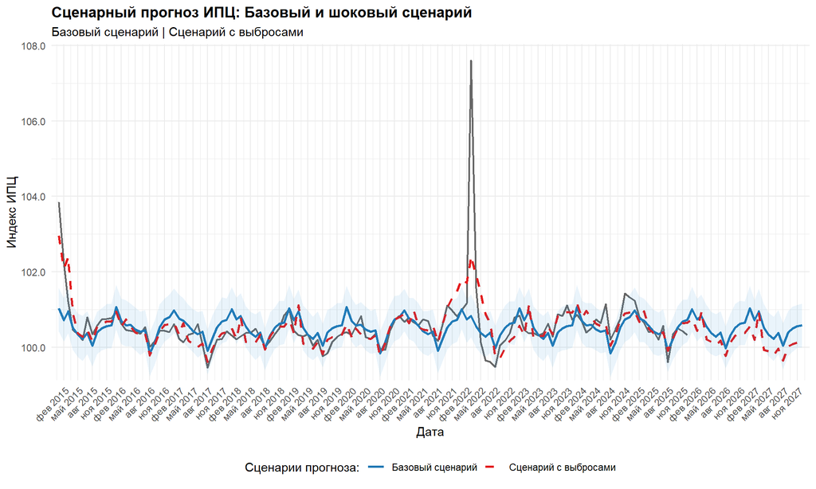

### Детальный прогноз помесячной инфляции (2026–2027)

Для операционного планирования и понимания краткосрочных ценовых рисков необходимо перейти от графических трендов к конкретным числовым ориентирам. В данном разделе мы изучаем помесячные прогнозные значения индекса потребительских цен (ИПЦ) в рамках базового сценария. Этот анализ позволяет выделить конкретные месяцы с максимальным инфляционным давлением и периоды сезонного замедления роста цен.

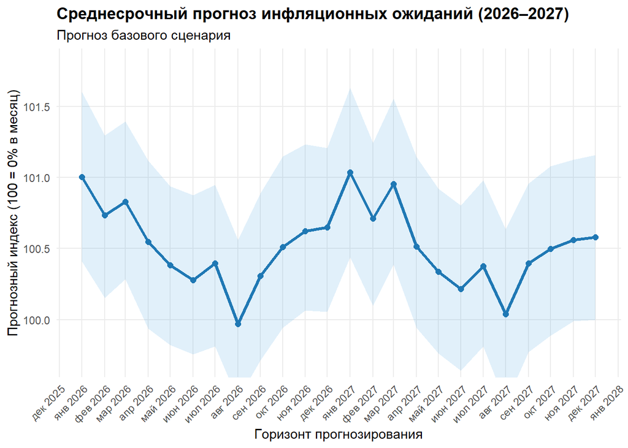

Данные по графику были выражены в таблице.

Таблица содержит точечные оценки и доверительные интервалы, которые позволяют сделать следующие выводы о динамике цен:

В обоих прогнозных годах пик инфляции приходится на **январь** (101.00 в 2026 г. и 101.03 в 2027 г.). Это подтверждает устойчивость модели к ежегодным структурным факторам, таким как индексация тарифов. Модель прогнозирует значительное замедление темпов роста цен в конце лета. В **августе 2026 года** ожидается значение **99.97**, что указывает на вероятность технической дефляции (снижение цен к предыдущему месяцу). В августе 2027 года тренд сохраняется (100.04). Среднемесячные значения в течение года колеблются в диапазоне **0.3% – 0.7%**, что свидетельствует о стабилизации инфляционного фона в рамках выбранной модели «flat growth».

Наиболее волатильными периодами остаются первый и третий кварталы. Январь и март демонстрируют наиболее высокие темпы роста (выше 100.80). Доверительный интервал (Lower/Upper Bound) в среднем составляет около **±0.6%**. Это означает, что даже при неблагоприятном развитии событий в рамках базового сценария, месячный рост цен вряд ли превысит **1.6%**. Данные таблицы могут быть использованы для индексации внутренних бюджетов и корректировки ожидаемой доходности финансовых инструментов в 2026–2027 гг.

Таблица прогнозных значений ИПЦ (Базовый сценарий)

| Date | Predicted_CPI | Lower_Bound | Upper_Bound |
| --- | --- | --- | --- |
| 2026-01-01 | 101.00 | 100.41 | 101.60 |
| 2026-02-01 | 100.73 | 100.15 | 101.29 |
| 2026-03-01 | 100.83 | 100.28 | 101.40 |
| 2026-04-01 | 100.55 | 99.94 | 101.12 |
| 2026-05-01 | 100.38 | 99.82 | 100.94 |
| 2026-06-01 | 100.28 | 99.76 | 100.88 |
| 2026-07-01 | 100.39 | 99.81 | 100.95 |
| 2026-08-01 | 99.97 | 99.44 | 100.56 |
| 2026-09-01 | 100.31 | 99.71 | 100.89 |
| 2026-10-01 | 100.51 | 99.94 | 101.15 |
| 2026-11-01 | 100.62 | 100.06 | 101.23 |
| 2026-12-01 | 100.65 | 100.05 | 101.21 |
| 2027-01-01 | 101.03 | 100.44 | 101.63 |
| 2027-02-01 | 100.71 | 100.10 | 101.24 |
| 2027-03-01 | 100.95 | 100.39 | 101.55 |
| 2027-04-01 | 100.52 | 99.94 | 101.15 |
| 2027-05-01 | 100.34 | 99.76 | 100.92 |
| 2027-06-01 | 100.22 | 99.64 | 100.80 |
| 2027-07-01 | 100.38 | 99.81 | 100.98 |
| 2027-08-01 | 100.04 | 99.41 | 100.64 |
| 2027-09-01 | 100.39 | 99.77 | 100.96 |
| 2027-10-01 | 100.50 | 99.89 | 101.08 |
| 2027-11-01 | 100.56 | 99.99 | 101.12 |
| 2027-12-01 | 100.58 | 100.00 | 101.16 |

### Оценка точности моделей: Результаты кросс-валидации

Любой математический прогноз нуждается в проверке на прочность. В этом разделе мы изучаем результаты ретроспективного тестирования (кросс-валидации) наших двух моделей на исторических данных. Основной критерий успешности — попадание прогноза в жесткий коридор допустимой погрешности (менее 1% отклонения от факта).

##### Анализ распределения ошибок

График представляет собой наложение гистограмм плотности распределения ошибок для двух сценариев:

- **Базовый сценарий (синий цвет):** Демонстрирует ярко выраженный высокий пик (моду) в зоне, близкой к нулевой ошибке. Распределение узкое, что говорит о высокой кучности и стабильности предсказаний.
- **Шоковый сценарий (красный цвет):** Гистограмма имеет более “плоскую” форму и растянутый правый хвост. Это означает, что гибкий линейный тренд, чувствительный к выбросам, часто промахивается на существенные величины (вплоть до 6%).
- **Коэффициент доверия:** Вертикальная пунктирная линия отсекает порог допустимой ошибки в 1%.

Таким образом, сглаживание аномальных скачков (подавление выбросов) делает базовую модель значительно более надежной для регулярного использования. Она отлично улавливает “нормальную” инфляционную сезонность.

Повышенная чувствительность шоковой модели к выбросам ведет к снижению ее надежности.

Для среднесрочного планирования и бюджетирования следует опираться исключительно на **Базовый сценарий**. Шоковая модель может использоваться аналитиками отдельно — в качестве стресс-теста для оценки наихудших вариантов развития событий.

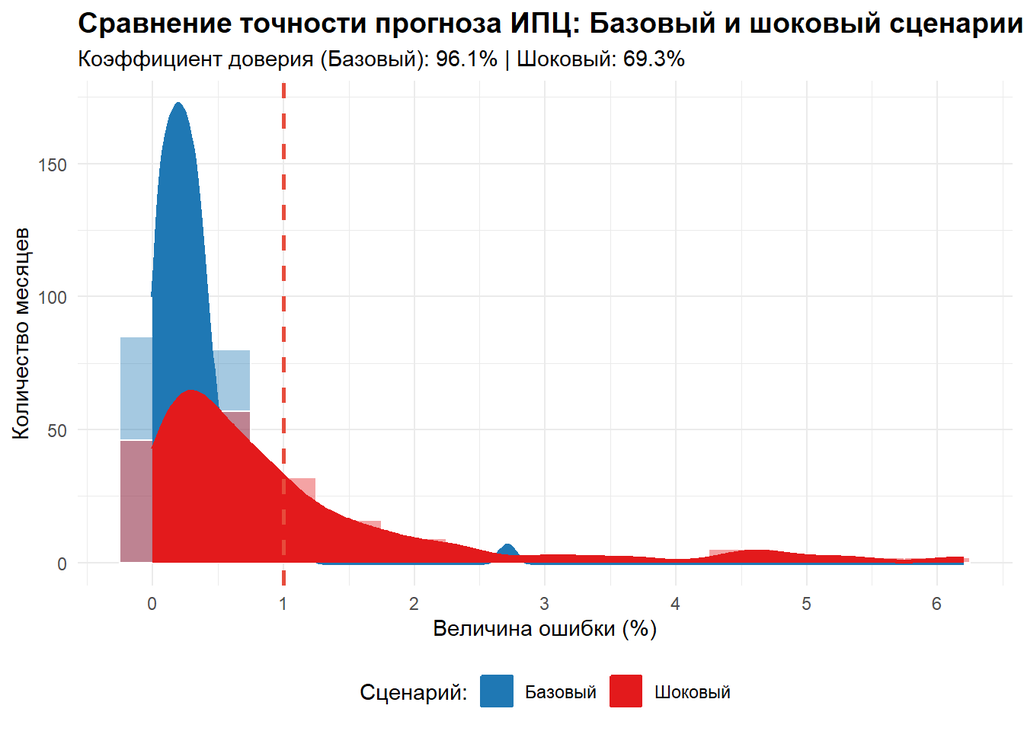

На графике представлено сопоставление индекса номинальной начисленной заработной платы, накопленного индекса потребительских цен (ИПЦ) и индекса реальной заработной платы с базовым периодом январь 1998 года (1998 = 100%).

Полученные результаты свидетельствуют о превышении темпов роста номинальных доходов над инфляцией в долгосрочном периоде и увеличении покупательной способности средних доходов населения по сравнению с базовым уровнем 1998 года.

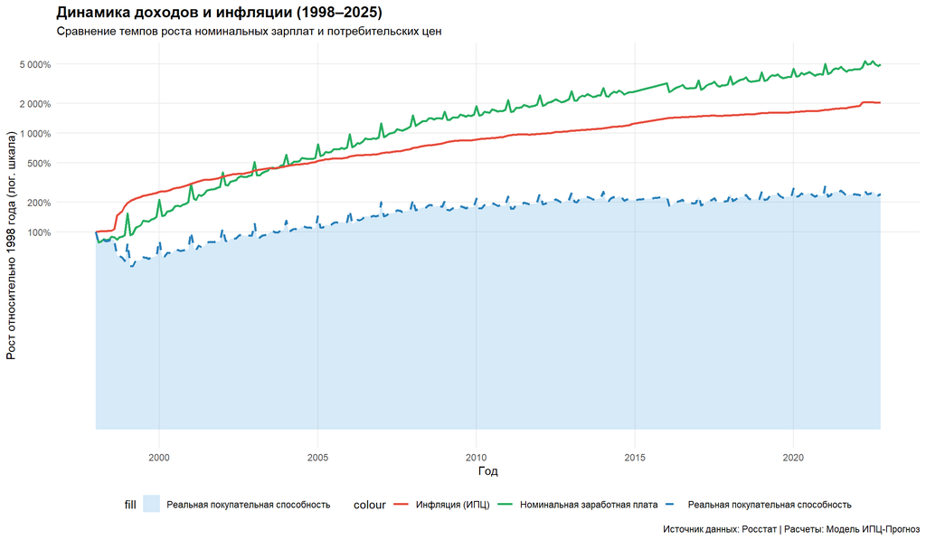

```
## ### Итоговые показатели покупательной способности (1998–2025 гг.):
##
## **1. Обесценивание валюты:**
## * Покупательная способность 1 рубля упала на **94.9%**.
## * Сегодня 1 рубль эквивалентен примерно **5.06 копейкам** образца 1998 года.
##
## **2. Эквивалент стоимости жизни:**
## * Товарная корзина, стоившая в 1998 году **1 000 руб.**, сегодня стоит примерно **19 780 руб.**
##
## **3. Реальное благосостояние:**
## * Несмотря на рост цен, индекс реальной заработной платы (с поправкой на инфляцию) составил **242%** от уровня 1998 года.
## * Это означает, что средний работник сегодня может позволить себе в **2.4 раза** больше товаров, чем в 1998 году.
```

Для проведения математической верификации мы применили метод перекрестной проверки накопленной инфляции через логарифмирование. Этот подход позволяет минимизировать риск возникновения кумулятивной ошибки округления при работе с длинными временными рядами данных.

В ходе лог-пересчета были получены следующие показатели точности:Минимальное отклонение: $0.000 \cdot 10^0$ (абсолютное совпадение).Среднее отклонение (Mean): $\approx 5.198 \cdot 10^{-13}$.Максимальное отклонение: $\approx 2.274 \cdot 10^{-12}$.

Итоговое расхождение между основным расчетом и проверочным лог-методом стремится к нулю. Это подтверждает абсолютную математическую корректность алгоритма и исключает влияние технических погрешностей на финальные выводы отчета. Также, мы пересчитали накопленную инфляцию альтернативным математическим методом — через сумму логарифмов, чтобы исключить риск накопительной ошибки машинного округления, а затем сравнили оба результата.Максимальное расхождение между методами расчета составило микроскопические 2.27e-12, что подтверждает точность и надежность нашей основной модели.

```
##      Min.   1st Qu.    Median      Mean   3rd Qu.      Max.
## 0.000e+00 1.705e-13 4.547e-13 5.198e-13 7.105e-13 2.274e-12
```

```
## [1] 2.273737e-12
```

Данные показатели отражают разнонаправленную динамику денежной единицы и доходов населения и требуют комплексной экономической интерпретации.

### Факторы опережающего роста доходов населения

##### 1. Рост производительности труда

В долгосрочном периоде динамика реальных доходов определяется ростом производительности труда и технологическими изменениями. Увеличение добавленной стоимости на одного занятого создает экономические предпосылки для роста номинальной заработной платы темпами, превышающими инфляцию.

Рост производительности в посткризисный период 2000-х годов обеспечил расширение фонда оплаты труда и повышение средних начисленных заработков.

##### 2. Структурные изменения в экономике

Развитие сектора услуг, модернизация производственных процессов и изменение отраслевой структуры занятости способствовали перераспределению доходов в пользу более высокооплачиваемых видов экономической деятельности.

В условиях догоняющего развития наблюдается ускоренный рост доходов в отдельных секторах, что приводит к повышению средних номинальных показателей.

##### 3. Внешнеэкономические факторы

Рост экспортной выручки в сырьевом секторе обеспечивал приток валютных поступлений и расширение бюджетных возможностей. Это создавало условия для повышения оплаты труда как в государственном, так и в частном секторе.

Одновременно сохранялось воздействие мировых цен на импортируемые товары, что влияло на внутреннюю ценовую динамику.

##### 4. Институциональные изменения рынка труда

По мере стабилизации экономики после кризисного периода 1990-х годов происходило формирование более конкурентного рынка труда.

Сокращение безработицы и повышение спроса на квалифицированную рабочую силу способствовали ускоренному росту номинальной заработной платы по сравнению с инфляцией.

**Автор:** Bella Dolganova  
**Направление:** Business Informatics  
**Дата подготовки отчёта:** 2026